# GTEx startup

Anna L Tyler

April 09, 2026

I’m going to try looking at the GTEx data here. Just more exploration.

```r
rm(list = ls())
library(here)
```

```r
all.fun <- list.files(here("Code"), full.names = TRUE)
for(i in 1:length(all.fun)){source(all.fun[i])}
```

```r
needed.libraries <- c("pheatmap", "DT", "gprofiler2", "vioplot",
  "VGAM", "parallel", "doParallel", "igraph")
load_libraries(needed.libraries)
```

There is just one big expression matrix, and I’ll need to parse out which individuals and tissues each sample belongs to. I’ve also downloaded the meta data for GTEx V8

```r
#This chunk takes a little while the first time through

sample.att <- as.matrix(read.delim(here("Data", "GTEx",
  "GTEx_Analysis_v8_Annotations_SampleAttributesDS.txt")))
ind.att <- as.matrix(read.delim(here("Data", "GTEx",
  "GTEx_Analysis_v8_Annotations_SubjectPhenotypesDS.txt")))

age.group <- sapply(strsplit(ind.att[,"AGE"], "-"), function(x) round(mean(as.numeric(x))))
ind.att <- cbind(ind.att, age.group)
ind.sex <- ind.att[,"SEX"]
ind.sex[which(ind.att[,"SEX"] == 1)] <- "Male"
ind.sex[which(ind.att[,"SEX"] == 2)] <- "Female"
ind.att <- cbind(ind.att, "sex" = ind.sex)

expr.file <- here("Data", "GTEx", "expression_individual.RDS")
gene.info.file <- here("Data", "GTEx", "info_gene.RDS")
sample.info.file <- here("Data", "GTEx", "info_sample.RDS")
if(!file.exists(expr.file)){
  #reading in this file takes several minutes
  expr <- read.delim(here("Data", "GTEx", "phASER_WASP_GTEx_v8_matrix.gw_phased.txt"))
  expr.info <- expr[,1:4]
  saveRDS(expr.info, gene.info.file)

  hap.levels <- expr[,5:ncol(expr)]

  sample.id <- gsub(".", "-", colnames(hap.levels), fixed = TRUE)
  ind.id <- sapply(strsplit(sample.id, "-"), function(x) paste(x[1], x[2], sep = "-"))
  samp.idx <- sapply(sample.id, function(x) which(sample.att[,1] == x))
  matched.sample.info <- sample.att[samp.idx,c("SAMPID", "SMTSD")]
  samp.info <- cbind(ind.id, matched.sample.info)
  saveRDS(samp.info, sample.info.file)

  #group expression by individual
  u_ind <- unique(ind.id)
  #length(u_ind)
  ind_expr <- lapply(u_ind, function(x) hap.levels[,which(samp.info[,1] == x),drop=FALSE])
  names(ind_expr) <- u_ind

  #split each individual into two matrices for the two haplotypes
  #and filter down to genes that are expressed.
  #this takes about half an hour on a laptop. Go make some tea.
  hap.expr <- vector(mode = "list", length = length(ind_expr))
  names(hap.expr) <- u_ind
  for(i in 1:length(ind_expr)){
    report.progress(i, length(ind_expr))
    hap1 <- apply(ind_expr[[i]], 2,
      function(x) as.numeric(sapply(strsplit(x, "|", fixed = TRUE), function(y) y[1])))
    hap2 <- apply(ind_expr[[i]], 2,
      function(x) as.numeric(sapply(strsplit(x, "|", fixed = TRUE), function(y) y[2])))
    rownames(hap1) <- rownames(hap2) <- sapply(strsplit(expr.info[,"name"], ".", fixed = TRUE), function(x) x[1])

    #replace sample IDs with tissue names
    samp.id <- colnames(hap1)
    tissue.id <- samp.info[match(gsub(".", "-", samp.id, fixed = TRUE), samp.info[,"SAMPID"]), "SMTSD"]
    colnames(hap1) <- colnames(hap2) <- tissue.id

    has.vals1 <- which(rowSums(hap1) > 0)
    has.vals2 <- which(rowSums(hap2) > 0)
    has.vals <- union(has.vals1, has.vals2)
    sub.hap1 <- hap1[has.vals,,drop=FALSE]
    sub.hap2 <- hap2[has.vals,,drop=FALSE]
    hap.list <- list("haplotype1" = sub.hap1, "haplotype2" = sub.hap2)
    hap.expr[[i]] <- hap.list
  }
  saveRDS(hap.expr, expr.file)
}else{
  hap.expr <- readRDS(expr.file)
}



gene.name.file <- here("Data", "GTEx", "gene_info.RDS")
if(!file.exists(gene.name.file)){
  all_gene <- unique(unlist(lapply(hap.expr, function(x) rownames(x[[1]]))))
  split.gene <- sapply(strsplit(all_gene, ".", fixed = TRUE), function(x) x[[1]])
  #gene.info <- gconvert(split.gene, organism = "hsapiens")
  gene.info <- get_gene_info(geneID = split.gene, IDtype = "ensembl_gene_id",
    organism = "human")
  saveRDS(gene.info, gene.name.file)
}else{
  gene.info <- readRDS(gene.name.file)
}
```

```r
gene_name <- function(gene.id = NULL, gene.name = NULL){
  if(is.null(gene.id)){
    gene.id <- gene.info[which(gene.info[,"external_gene_name"] == gene.name),"ensembl_gene_id"]
    if(length(gene.id) == 0){
      stop(paste("I can't find the gene", gene.name))
    }
  }
  if(is.null(gene.name)){
    gene.name <- gene.info[which(gene.info[,"ensembl_gene_id"] == gene.id),"external_gene_name"]
    if(length(gene.name) == 0){
      stop(paste("I can't find the gene", gene.id))
    }
  }
  result <- c("name" = as.character(gene.name), "id" = as.character(gene.id))
}

comp_binom <- function(haplotype.table){

  #remove rows with all zeros or nas
  not.na <- which(!is.na(rowSums(haplotype.table)))
  sub.table <- haplotype.table[not.na,]
  #plot(sub.table)

  fit.bb <- try(vglm(sub.table ~ 1, family=betabinomial), silent = TRUE)
  if(class(fit.bb) == "try-error"){
    return(NA)
  }
  fit.b <- vglm(sub.table~1, binomialff)
  loglik.bb <- logLik(fit.bb)
  loglik.b <- logLik(fit.b)

  lambda_lr <- (loglik.b - loglik.bb)*-2
  p <- 1-pchisq(lambda_lr, df = 1)
  return(p)
}

test_gene_fit <- function(gene.name = NULL, gene.id = NULL, tissue.name = NULL){

  gene.info <- gene_name(gene.id, gene.name)
  gene.name <- gene.info["name"]
  gene.id <- gene.info["id"]

  #get the expression across tissues for each individual
  hap1.expr <- lapply(hap.expr, function(x) x[[1]][which(rownames(x[[1]]) == gene.id),])
  hap2.expr <- lapply(hap.expr, function(x) x[[2]][which(rownames(x[[2]]) == gene.id),])

  if(!is.null(tissue.name)){
    hap1.tissue <- lapply(hap1.expr, function(x) x[grep(tissue.name, names(x), ignore.case = TRUE),drop=FALSE])
    hap2.tissue <- lapply(hap2.expr, function(x) x[grep(tissue.name, names(x), ignore.case = TRUE),drop=FALSE])
    plot.label <- paste(gene.name, tissue.name)
  }else{
    hap1.tissue <- hap1.expr
    hap2.tissue <- hap2.expr
    plot.label <- paste(gene.name, "all tissues")
  }

  has.vals <- which(sapply(hap1.tissue, length) > 0)
  paired.haps <- lapply(has.vals, function(x) cbind(hap1.tissue[[x]], hap2.tissue[[x]]))
  all.hap1 <- Reduce("c", lapply(paired.haps, function(x) x[,1]))
  all.hap2 <- Reduce("c", lapply(paired.haps, function(x) x[,2]))

  fit.p <- sapply(paired.haps, comp_binom)
  return(fit.p)
}

#tests all genes for a given individual
test_ind_genes <- function(ind_expr, tissue = NULL, verbose = FALSE){
  hap1 <- ind_expr[[1]]
  hap2 <- ind_expr[[2]]
  if(!is.null(tissue)){
    tissue.idx <- grep(tissue, colnames(hap1), ignore.case = TRUE)
    if(length(tissue.idx) <= 5){
      return(NA)
    }
  }
  if(verbose){
    gene.p <- unlist(lapply_pb(1:nrow(hap1), function(x) comp_binom(cbind(hap1[x,], hap2[x,]))))
  }else{
    gene.p <- sapply(1:nrow(hap1), function(x) comp_binom(cbind(hap1[x,], hap2[x,])))
  }
  names(gene.p) <- rownames(hap1)
  gene.p <- gene.p[which(!is.na(gene.p))]
  return(gene.p)
}


plot_gene_cor <- function(gene.name = NULL, gene.id = NULL,
  tissue.name = NULL, plot.results = TRUE){

  gene.info <- gene_name(gene.id, gene.name)
  gene.name <- gene.info["name"]
  gene.id <- gene.info["id"]

  #get the expression across tissues for each individual
  hap1.expr <- lapply(hap.expr, function(x) x[[1]][which(rownames(x[[1]]) == gene.id),])
  hap2.expr <- lapply(hap.expr, function(x) x[[2]][which(rownames(x[[2]]) == gene.id),])

  if(!is.null(tissue.name)){
    hap1.tissue <- lapply(hap1.expr, function(x) x[grep(tissue.name, names(x), ignore.case = TRUE),drop=FALSE])
    hap2.tissue <- lapply(hap2.expr, function(x) x[grep(tissue.name, names(x), ignore.case = TRUE),drop=FALSE])
    plot.label <- paste(gene.name, tissue.name)
  }else{
    hap1.tissue <- hap1.expr
    hap2.tissue <- hap2.expr
    plot.label <- paste(gene.name, "all tissues")
  }

  has.vals <- which(sapply(hap1.tissue, length) > 0)
  paired.haps <- lapply(has.vals, function(x) cbind(hap1.tissue[[x]], hap2.tissue[[x]]))
  all.hap1 <- Reduce("c", lapply(paired.haps, function(x) x[,1]))
  all.hap2 <- Reduce("c", lapply(paired.haps, function(x) x[,2]))

  #test.check <- sapply(paired.haps, comp_binom)
  #qqunif.plot(test.check)

  hap.cor <- sapply(paired.haps, function(x) cor(x[,1], x[,2], method = "spearman"))
  hap.ratios <- lapply(paired.haps, function(x) x[,1]/rowSums(x))

  if(plot.results){
    par(mfrow = c(1,3))
    plot.with.model(all.hap1, all.hap2, xlab = "Haplotype 1", ylab = "Haplotype 2",
      pch = 16, main = gene.name, report = "cor.test")
    hist(hap.cor, xlab = "Spearman correlation", breaks = 50,
      main = "Haplotype Correlation", xlim = c(-1, 1))
    abline(v = 0, col = "red")
    mtext(plot.label, side = 3, outer = TRUE, line = -1.5, cex = 1.2, font = 2)
    hist(unlist(hap.ratios), main = "Allele Ratios", xlab = "ratio", xlim = c(0, 1))
  }

  result <- list("correlations" = hap.cor, "haplotype_counts" = paired.haps,
    "ratios" = hap.ratios)
  invisible(result)
}

get_ind_expr <- function(gene.name = NULL, gene.id = NULL,
  ind.name, plot.results = FALSE){

  gene.info <- gene_name(gene.id, gene.name)
  gene.name <- gene.info["name"]
  gene.id <- gene.info["id"]

  ind.idx <- which(names(hap.expr)== ind.name)
  if(length(ind.idx) == 0){
    stop(paste("I can't find the individual", ind.name))
  }

  ind.expr <- hap.expr[[ind.idx]]
  gene.idx <- which(rownames(ind.expr[[1]]) == gene.id)

  #get the expression across tissues for each individual
  hap1.expr <- ind.expr[[1]][which(rownames(ind.expr[[1]]) == gene.id),]
  hap2.expr <- ind.expr[[2]][which(rownames(ind.expr[[2]]) == gene.id),]

  paired.haps <- cbind(hap1.expr, hap2.expr)

  if(plot.results){
    xlim <- c(min(hap1.expr, na.rm = TRUE), (max(hap1.expr, na.rm = TRUE)*1.1))
    plot(hap1.expr, hap2.expr, xlab = "Haplotype 1", ylab = "Haplotype 2",
      pch = 16, main = gene.name, xlim = xlim)
    text(hap1.expr, hap2.expr, labels = names(hap1.expr), cex = 0.6,
      pos = 4)
    abline(0,1)
  }

  return(paired.haps)
}
```

```r
imprinted.genes <- c("FAM50B", "PXDC1", "GRB10", "PLAGL1", "HYMAI")
gene.cor <- lapply(imprinted.genes, plot_gene_cor)
names(gene.cor) <- imprinted.genes

par(mfrow = c(1,2))
boxplot(lapply(gene.cor, function(x) x[[1]]), main = "Correlations")
abline(h = c(0, 0.5))
boxplot(lapply(gene.cor, function(x) x[[2]]), main = "Ratios")
abline(h = 1)

imprinted <- plot_gene_cor(gene.name = "HYMAI")
imprinted.p <- test_gene_fit("HYMAI")
imprinted.fdr <- p.adjust(imprinted.p, method = "BH")
qqunif.plot(imprinted.fdr)
which(imprinted.fdr <= 0.1)

plot(-log10(imprinted.fdr), -log10(biallele.fdr))


biallele <- plot_gene_cor("GAB1")
biallele.p <- test_gene_fit("GAB1")

biallele.fdr <- p.adjust(biallele.p, method = "BH")
qqunif.plot(biallele.fdr)
which(biallele.fdr <= 0.1)


imprinted$haplotype_counts[which(imprinted.fdr <= 0.1)]
biallele$haplotype_counts[which(biallele.fdr <= 0.1)]

test.mat <- biallele$haplotype_counts[which(biallele.fdr <= 0.1)][[1]]
pheatmap(test.mat)
comp_binom(test.mat)

par(mfrow = c(1,2))
qqunif.plot(biallele.p, plot.label = "biallelic")
qqunif.plot(imprinted.p, plot.label = "imprinted")

test <- plot_gene_cor("KCNK9")
plot_gene_cor("KCNK9", tissue.name = "brain")

plot_gene_cor("KL")
plot_gene_cor("KL", tissue.name = "brain")
```

```r
plot_expr_as_mat <- function(cor_result, plot.label = ""){
  hap.result <- cor_result$haplotype_counts
  ind.idx <- match(names(hap.result), ind.att[,"SUBJID"])

  ind.sex <- as.factor(ind.att[ind.idx,"sex"])
  ind.age.group <- as.numeric(ind.att[ind.idx,"age.group"])
  annot.df <- data.frame("age.group" = rep(ind.age.group, each = 2),
    "sex" = rep(ind.sex, each = 2))
  rownames(annot.df) <- paste(rep(names(hap.result), each = 2), c(1,2), sep = "_")

  all.tx <- unique(unlist(lapply(hap.result, rownames)))

  all.expr <- vector(mode = "list", length = length(hap.result))
  names(all.expr) <- names(hap.result)

  for(i in 1:length(hap.result)){
    ind.mat <- matrix(NA, nrow = length(all.tx), ncol = 2)
    rownames(ind.mat) <- all.tx
    tx <- rownames(hap.result[[i]])
    ind.mat[tx,] <- hap.result[[i]]
    all.expr[[i]] <- ind.mat
  }

  ind.order <- order(sapply(all.expr, function(x) mean(x, na.rm = TRUE)))
  expr.mat <- Reduce("cbind", all.expr[ind.order])
  colnames(expr.mat) <- rownames(annot.df)
  row.order <- order(rowMeans(expr.mat, na.rm = TRUE))

  pheatmap(log10(expr.mat[row.order,]+1), annotation_col = annot.df,
    cluster_rows = FALSE, cluster_cols = FALSE, main = plot.label, show_colnames = FALSE)
}


plot_deviations <- function(cor_result, main = "", log.transform = TRUE,
  plot.results = TRUE, ratio.thresh = 0.9){
  #collect all haplotypes

  all.haps <- cbind(unlist(lapply(cor_result$haplotype_counts, function(x) x[,1])),
    unlist(lapply(cor_result$haplotype_counts, function(x) x[,2])))
  if(log.transform){
    all.haps <- log10(all.haps+1)
  }
  #plot(log10(all.haps+1))
  ratios <- all.haps[,1]/rowSums(all.haps)
  above.thresh <- which(ratios >= ratio.thresh)
  below.thresh <- which(ratios <= 1-ratio.thresh)

  dev.haps <- all.haps[c(names(above.thresh), names(below.thresh)),]

  above.ind <- Reduce("rbind", strsplit(names(above.thresh), ".", fixed = TRUE))
  below.ind <- Reduce("rbind", strsplit(names(below.thresh), ".", fixed = TRUE))
  skewed.ratios <- rbind(above.ind, below.ind)
  ordered.table <- skewed.ratios[order(skewed.ratios[,1]),]
  rownames(ordered.table) <- NULL

  if(plot.results){
    layout.mat <- matrix(c(1,2,3,4), nrow = 2, byrow = FALSE)
    layout(layout.mat, widths = c(0.8, 1))

    pt.col <- rep("black", nrow(all.haps))
    pt.col[above.thresh] <- "red"
    pt.col[below.thresh] <- "blue"
    plot(all.haps[,1], all.haps[,2], xlab = "Haplotype 1",
      ylab = "Haplotype 2", col = pt.col, main = main, pch = 16)
    abline(0,1)

    hist(ratios, main = "ratios", xlab = "ratios")
    abline(v = c(ratio.thresh, 1-ratio.thresh))

    #pheatmap(log10(dev.haps+1))
    par(mar = c(4, 16, 0, 2))
    imageWithText(log10(dev.haps+1), show.text = FALSE,
      use.pheatmap.colors = TRUE, row.text.shift = 0.5,
      row.text.cex = 0.7)

    par(mar = c(4, 16, 0, 2))
    barplot(sort(ratios[c(above.thresh, below.thresh)]),
      las = 2, horiz = TRUE, cex.names = 0.7,
      xlab = "Allele Ratio")
    plot.dim <- par("usr")
    segments(x0 = 0.5, y0 = -1, y1 = plot.dim[4]-1)

  }
  invisible(ordered.table)
}
```

```r
gene.name = "KL"
test <- plot_gene_cor(gene.name)
#quartz(width = 11, height = 6)
deviants <- plot_deviations(test, main = gene.name, ratio.thresh = 0.9,
  log.transform = TRUE)


#quartz(width = 11, height = 6)
show.max <- min(20, nrow(deviants))
par(mfrow = c(1,2), mar = c(4,10,4,2))
barplot(rev(sort(table(deviants[,1]), decreasing = TRUE)[1:show.max]),
  las = 2, horiz = TRUE, main = "Individuals with skewed ratios",
  xlab = "Tissues", cex.names = 0.8)
par(mar = c(4,10,4,2))
barplot(rev(sort(table(deviants[,2]), decreasing = TRUE)[1:show.max]),
  las = 2, horiz = TRUE, cex.names = 0.8,
  main = "Tissues with skewed ratios", xlab = "Individuals")
mtext(gene.name, outer = TRUE, side = 3, line = -2.5, font = 2, cex = 1.2)

plot_expr_as_mat(test, gene.name)

high.ind <- sort(table(deviants[,1]), decreasing = TRUE)
all.ind.p <- sapply(names(high.ind), function(x) comp_binom(get_ind_expr(gene.name, x)))
sig.ind <- which(all.ind.p < 0.00001)

par(mfrow = c(3,3))
for(i in 1:length(sig.ind)){
  test.ind <- get_ind_expr(gene.name, names(sig.ind)[i])
  plot(log10(test.ind), pch = 16, xlim = c(0, 3))
  text(log10(test.ind[,1]), log10(test.ind[,2]), labels = rownames(test.ind),
    pos = 4, cex = 0.5)
  abline(0,1)
}


test.ratio <- test.ind[,1]/rowSums(test.ind)
test.ratio <- test.ratio[which(!is.na(test.ratio))]
ratio.order <- order(test.ratio)
barplot(test.ratio[ratio.order], las = 2)
imageWithText(log10(test.ind[ratio.order,]+1), use.pheatmap.colors = TRUE,
  show.text = FALSE, row.text.shift = 0.5)

test.age <- as.numeric(ind.att[match(names(test$correlations),
  ind.att[,"SUBJID"]), "age.group"])
mean.expr <- sapply(test$haplotype_counts, function(x) mean(log10(x+1)))

expr.by.age <- lapply(unique(test.age), function(x) mean.expr[which(test.age == x)])
names(expr.by.age) <- unique(test.age)

cor.by.age <- lapply(unique(test.age), function(x) test$correlations[which(test.age == x)])
names(cor.by.age) <- unique(test.age)


par(mfrow = c(1,2))
vioplot(expr.by.age, main = "Expression by age", col = "lightgray")
mtext("age group", side = 1, line = 2.5)
mtext("log expression", side = 2, line = 2.5)
stripchart(expr.by.age, vertical = TRUE, method = "jitter", pch = 16,
  col = "#dd1c77", add = TRUE, cex = 0.5)

vioplot(cor.by.age, main = "Haplotype correlation by age", col = "lightgray")
mtext("age group", side = 1, line = 2.5)
mtext("Spearman correlation", side = 2, line = 2.5)
stripchart(cor.by.age, vertical = TRUE, method = "jitter", pch = 16,
  col = "#dd1c77", add = TRUE, cex = 0.5)

mtext(gene.name, side = 3, outer = TRUE, line = -1.5, cex = 1.2, font = 2)
```

```r
gene.name <- c("MAPK1", "ARL17A", "PARD6G")
test.results <- vector(mode = "list", length = length(gene.name))
names(test.results)  <- gene.name

pdf("~/Desktop/check_genes.pdf", width = 8, height = 4)
for(i in 1:length(gene.name)){
  report.progress(i, length(gene.name))
  test.results[[i]] <- plot_gene_cor(gene.name[i])
}
dev.off()
```

the stats tell us if a given gene has biased

allele expression in a single individual (gene x individual) how many genes in each individual have biased expression? in how many individuals does each gene have biased expression?

genes x tissues x individuals

for each gene count how many individuals have skew in each tissue

for each individual count how many genes are skewed in each tissue for each tissue count

```r
all_p_file <- here("Results", "processed_data", "Individual_Gene_P_values.RDS")

if(!file.exists(all_p_file)){
  # Parallel computation using 4 cores
  #cl <- makeCluster(detectCores()-1)
  #cl <- makeCluster(4)
  cl <- makeCluster(20)
  registerDoParallel(cl)
  clusterExport(cl, c("test_ind_genes", "comp_binom", "vglm", "betabinomial",
    "binomialff", "logLik", "pchisq", "try"))
  #all_p <- foreach(ind_expr = hap.expr[1:4]) %dopar% test_ind_genes(ind_expr)
  all_p <- foreach(ind_expr = hap.expr) %dopar% test_ind_genes(ind_expr)
  stopCluster(cl)
  saveRDS(all_p, all_p_file)
}else{
  all_p <- readRDS(all_p_file)
}
```

```r
brain_p_file <- here("Results", "processed_data", "Individual_Gene_P_values_brain.RDS")

if(!file.exists(brain_p_file)){
  # Parallel computation using 4 cores
  #cl <- makeCluster(detectCores()-1)
  #cl <- makeCluster(4)
  cl <- makeCluster(20)
  registerDoParallel(cl)
  clusterExport(cl, c("test_ind_genes", "comp_binom", "vglm", "betabinomial",
    "binomialff", "logLik", "pchisq", "try"))
  #all_p <- foreach(ind_expr = hap.expr[1:4]) %dopar% test_ind_genes(ind_expr)
  brain_p <- foreach(ind_expr = hap.expr) %dopar% test_ind_genes(ind_expr)
  stopCluster(cl)
  saveRDS(all_p, all_p_file)
}else{
  all_p <- readRDS(all_p_file)
}
```

```r
alpha.thresh <- 1e-6
```

## Number of biased genes per individual

There were many genes, even at a very conservative, threshold that had significantly biased gene expression (adjusted p < 10^{-6}). The histogram below shows the distribution of biased genes per individual.

Most people had fewer than 1000 biased genes, but some had many more.

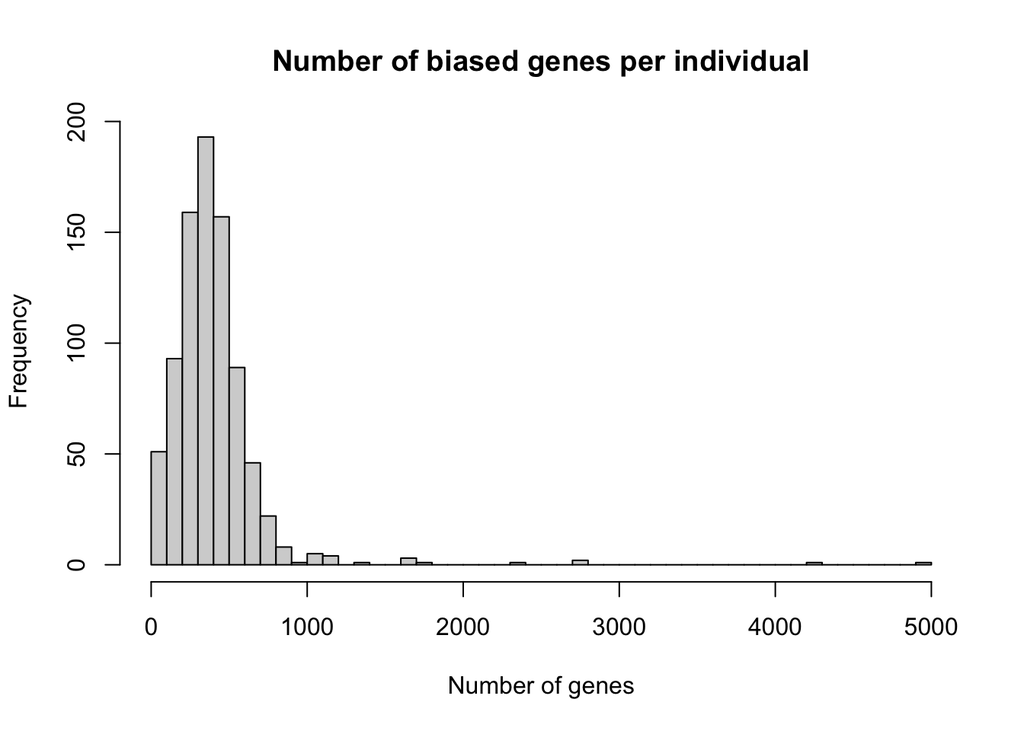

```r
adj.p <- lapply(all_p, function(x) p.adjust(x, "BH"))
sig.p <- lapply(adj.p, function(x) which(x <= alpha.thresh))
names(sig.p) <- names(hap.expr)
num.sig <- sapply(sig.p, length)
hist(num.sig, breaks = 50,
  main = "Number of biased genes per individual", xlab = "Number of genes")
```

## Cause of the inter-individual variation

The main driver of the number of genes identified as having biased expression, seems to be the number of tissues that were measured. Having more tissues measured gives you greater power to detect biased gene expression. The plot below shows how the number of biased genes changes as a function of the number of tissues measured. The relationship is very strong, although there are also some crazy outliers.

This means that in order to look at inter-individual variation in the number of biased genes, we’ll need to do some different statistics. We could re-sample at a lower rate, but this will result in a lot of false negatives. What about an adaptive p value threshold that takes into account the number of tissues measured in each person? That seems as if it risks a lot of false positives…

Could we do some combination of those things?

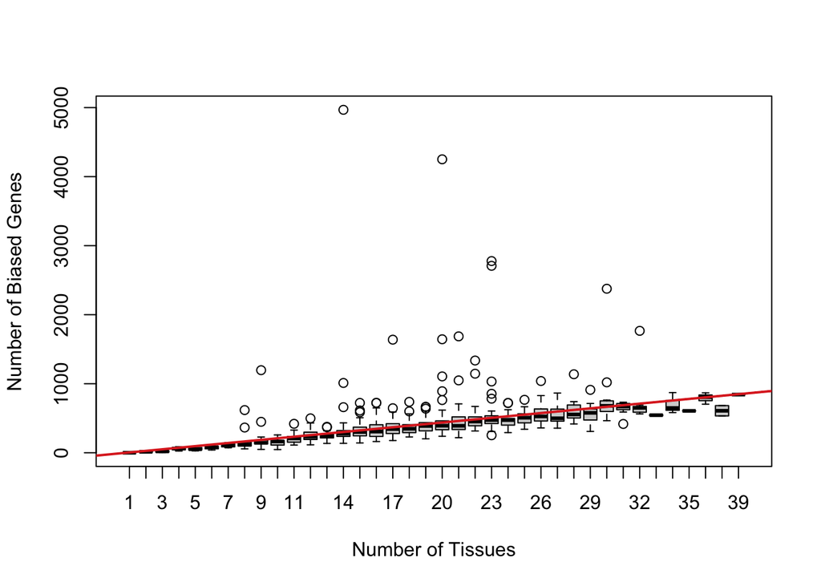

```r
num.tissues <- sapply(hap.expr, function(x) ncol(x[[1]]))
boxplot(num.sig~num.tissues,
  ylab = "Number of Biased Genes", xlab = "Number of Tissues")
model <- lm(num.sig~num.tissues)
abline(model, lwd = 2, col = "#de2d26")
```

```r
#brain.idx <- sapply(hap.expr, function(x) grep("brain", colnames(x[[1]]), ignore.case = TRUE))
#num.brain <- sapply(brain.idx, length)
#hist(num.brain)
```

## Adaptive p values

Below we look at what kinds of thresholds it would take to even out the number of biased genes per individual.

```r
med.num <- round(median(sapply(num.sig, median)))
```

The plot below shows at what p value cutoff you can detect 362 genes (which is the median number of genes detected across all patients at p = 10^{-6}) as a function of the number of tissues sampled.

The horizontal line shows the cutoff p = 0.01.

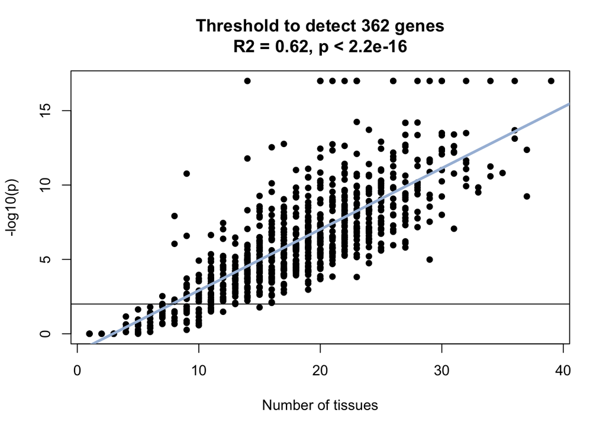

```r
find_thresh <- function(pV, target.num){
  sorted.p <- sort(pV, decreasing = FALSE)
  #plot(-log10(sorted.p+1e-17))
  #abline(v = target.num)
  target.p <- sorted.p[round(target.num)]
  return(target.p)
}

adaptive.thresh <- sapply(adj.p, function(x) find_thresh(x, med.num))
#hist(-log10(adaptive.thresh+1e-17), breaks = 50)


plot.with.model(num.tissues, -log10(adaptive.thresh+1e-17),
  xlab = "Number of tissues", ylab = "-log10(p)",
  main = paste("Threshold to detect", med.num, "genes"))
abline(h = -log10(0.01))
```

Also, each of these people has different tissues measured, which could affect which genes are detected, but I think we probably can’t worry about that.

```r
max.p <- 0.01
```

## Implementing adaptive p value

The plot below shows the number of significantly biased genes, if we use the p value threshold derived from the number of tissues sampled. We set a maximum adjusted p value threshold at 0.01.

There is no longer a relationship between the number of significantly biased genes and the number of tissues sampled. I’m not sure if this is valid…

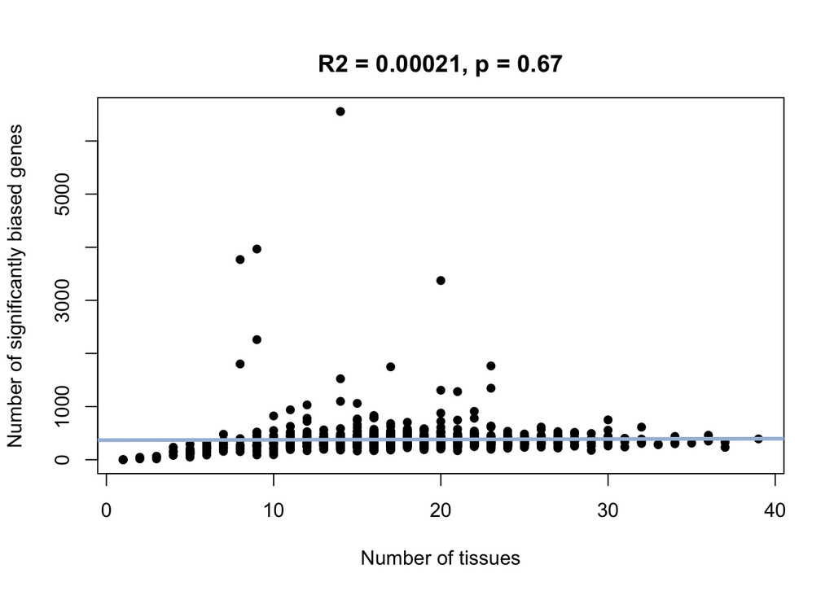

```r
model <- lm(-log10(adaptive.thresh+1e-17)~num.tissues)
coefs <- coef(model)
thresh.by.tissue <- sapply(1:40, function(x) (coefs[2]*x)+coefs[1])
p.by.tissue <- 10^(thresh.by.tissue*-1)
p.by.tissue[which(p.by.tissue > max.p)] <- max.p
#set a threshold for each individual based on the number
#of tissues they had measured
ind.thresh <- sapply(num.tissues, function(x) p.by.tissue[x])

new.sig <- lapply(1:length(adj.p), function(x) which(adj.p[[x]] <= ind.thresh[x]))
names(new.sig) <- names(sig.p)
num.new.sig <- sapply(new.sig, length)
#hist(num.new.sig, breaks = 50)

plot.with.model(num.tissues, num.new.sig, xlab = "Number of tissues",
ylab = "Number of significantly biased genes")
```

## No relationship with bias and sex or age

The plots below show that there is no relationship between the number of significantly biased genes and age or sex. I’m showing the log10 of significantly biased genes, because some individuals have huge numbers.

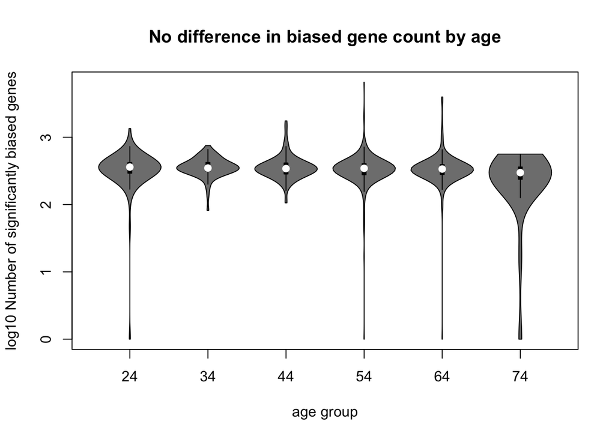

```r
ind.idx <- match(names(new.sig), ind.att[,1])
vioplot(log10(num.new.sig+1)~as.numeric(ind.att[ind.idx,"age.group"]),
  xlab = "age group", ylab = "log10 Number of significantly biased genes",
  main = "No difference in biased gene count by age")
```

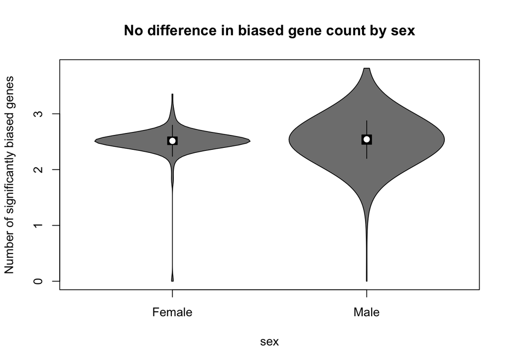

```r
vioplot(log10(num.new.sig+1)~as.factor(ind.att[ind.idx,"sex"]),
  xlab = "sex", ylab = "Number of significantly biased genes",
  main = "No difference in biased gene count by sex")
```

## Number of shared genes

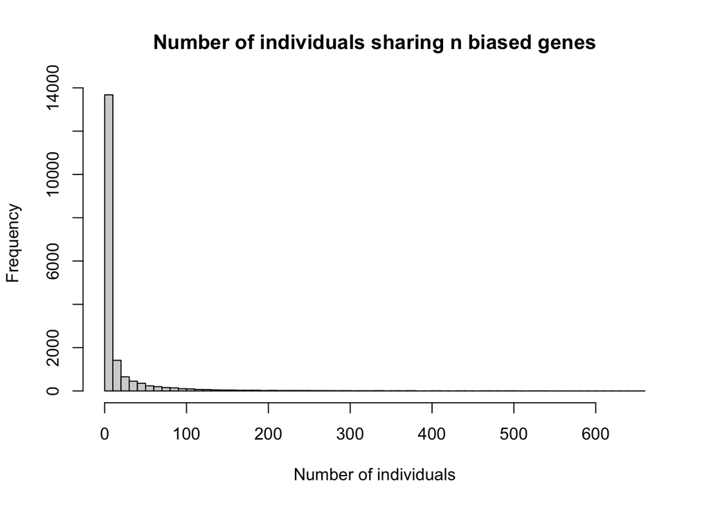

```r
u_genes <- unique(unlist(lapply(new.sig, names)))
inc.mat <- matrix(0, nrow = length(new.sig), ncol = length(u_genes))
rownames(inc.mat) <- names(new.sig)
colnames(inc.mat) <- u_genes
for(i in 1:length(new.sig)){
  inc.mat[i,names(new.sig[[i]])] <- 1
}
genes.shared <- colSums(inc.mat)
hist(genes.shared, breaks = 50, xlab = "Number of individuals",
  main = 'Number of individuals sharing n biased genes')
```

Not surprisingly, this distribution is close to a power law, but not quite.

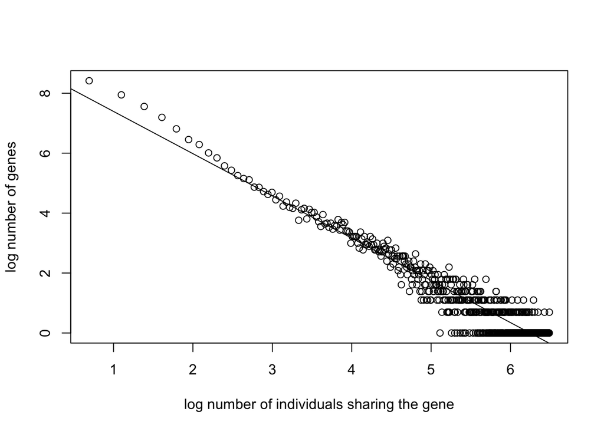

```r
num.shared <- 1:max(genes.shared)
shared.by <- sapply(num.shared, function(x) length(which(genes.shared == x)))
#plot(num.shared, shared.by, log = "xy")
plot(log(num.shared+1), log(shared.by+1),
  xlab = "log number of individuals sharing the gene",
  ylab = "log number of genes")

test <- lm(log(shared.by+1)~log(num.shared+1))
#summary(test)
abline(test)
```

The number of genes shared by at least n people is shown below. The horizontal line shows y = 100.

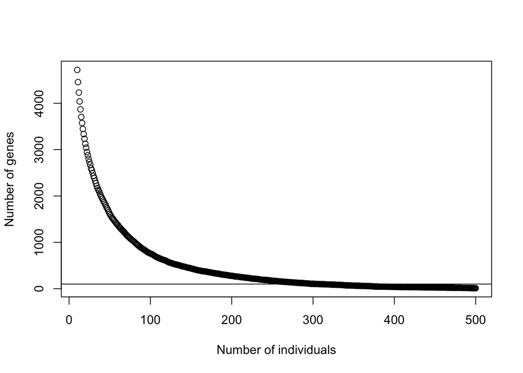

```r
#collect all genes shared by each number of individuals
shared.genes <- lapply(1:max(num.shared), function(x) colnames(inc.mat)[which(genes.shared == x)])
names(shared.genes) <- 1:max(num.shared)

#make lists of genes with at least x number of individuals sharing biased expression
count.shared <- 10:500
at.least.some <- lapply(count.shared, function(x) unlist(shared.genes[x:length(shared.genes)]))
at.least.num <- sapply(at.least.some, length)
names(at.least.num) <- count.shared
plot(count.shared, at.least.num, xlab = "Number of individuals",
  ylab = "Number of genes")
abline(h = 100)
```

## Enrichments for shared genes

The enrichment plots below show functional enrichments for biased genes shared by at least n people. There are a lot of extracellular enrichments in the less shared genes, and a lot of immunological enrichments in the more shared genes.

```r
for(i in seq(200, 500, 100)){
  cat("###", i, "genes\n")
  enrich <- gost(at.least.some[[which(count.shared == i)]],
    organism = "hsapiens", sources = c("GO", "KEGG", "HPA"))
  plot.enrichment(enrich, num.terms = 30,
    plot.label = paste("Biased genes shared by at least", i, "people"))
  cat("\n\n")
}
```

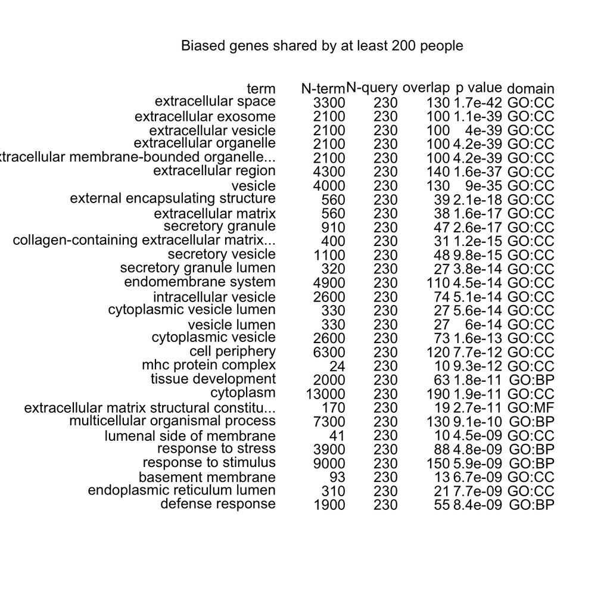

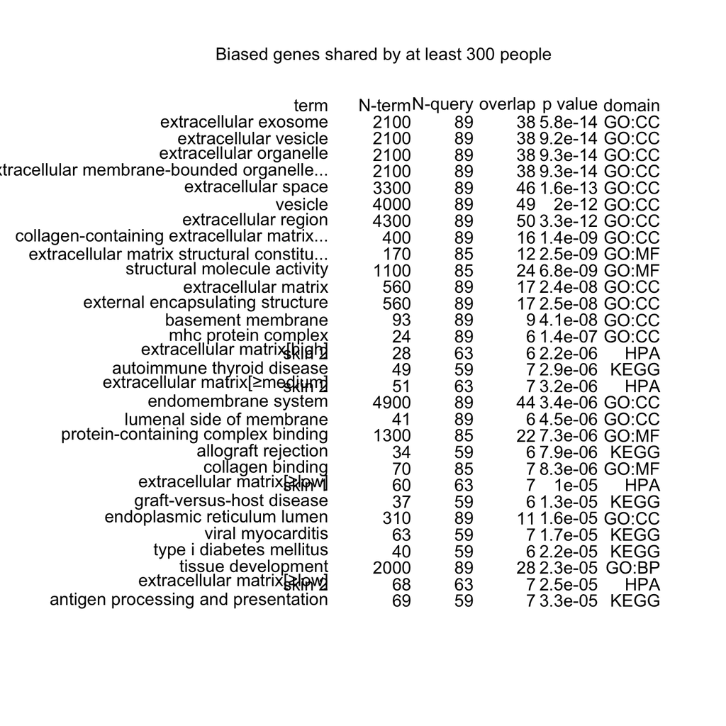

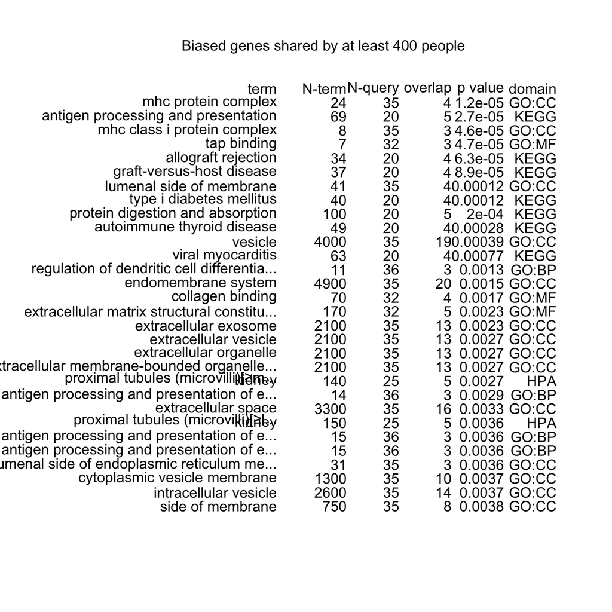

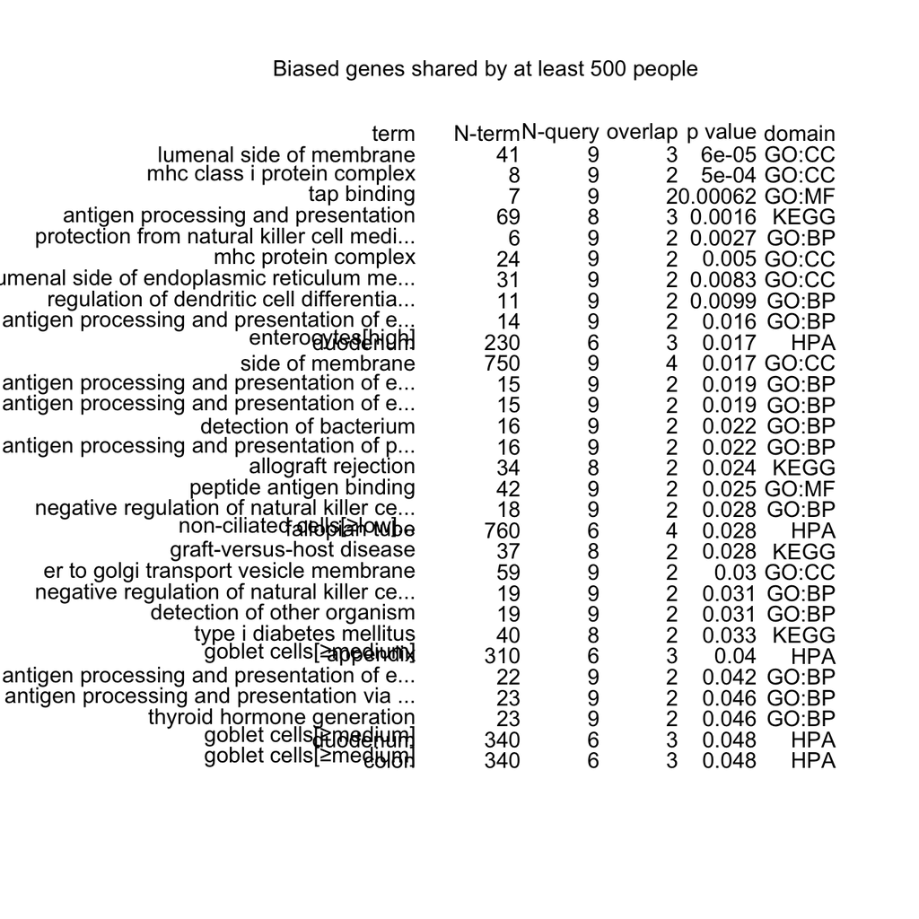

```r
genes.which <- at.least.some[[which(count.shared == 200)]]

#pheatmap(inc.mat[,genes.which], show_rownames = FALSE)
plot.decomp(inc.mat[,genes.which],
  color.by = ind.att[match(rownames(inc.mat), ind.att[,1]),"sex",drop=FALSE]) #dots are individuals

plot.decomp(t(inc.mat[,genes.which])) #dots are genes

inc.net <- graph_from_incidence_matrix(inc.mat[,genes.which])
inc.proj <- bipartite_projection(inc.net)

ind.proj <- inc.proj[[1]]
gene.proj <- inc.proj[[2]]

degree(ind.proj)
degree(gene.proj)
```

```r
#too many! Even 10 takes a long time
#ind.enrich <- lapply(lapply(new.sig, names)[1:10], function(x) gost(x, organism = "hsapiens"))
#plot.enrichment.group(ind.enrich)
```